# Practical Machine Learning Project

MF

12/6/2022

## Introduction

This project is based on accelerometer data from a number of participants. The objective is to predict the manor they did the exercise defined by the “classe” variable in the training set. There are some problems assessing the web page with the general information, but the datafiles can be downloaded.

The analysis is divided into: *Data loading* Data cleaning *Parameter identification using a decision treee* Model training *Model forecast

## Loading Modules to be used

```r
knitr::opts_chunk$set(echo = TRUE)
library(caret)
library(rpart)
library(randomForest)
```

```r
library(rattle) # Plotting decision tree
```

## Data Loading and cleaning

Import the csv files for training and testing provided. Then remove columns where non-assigned values represent 80 percent or more of the information. Columns 1 to 7 are irrelevant and have been removed as they refer to user names and system setup.

The project contains two files, a training set and a forecast set. The training set is divided into a training and testing test to generate and qualify the accuracy of the model fit.

Columns contraining 80 percent of more non assigned values were removed from the training and test data.

```r
training <- read.csv("pml-training.csv", na.strings=c("NA","#DIV/0!", ""))
training <- training[,colMeans(is.na(training)) < 0.80]
training <- training[,-c(1:7)]

testing <- read.csv("pml-testing.csv", na.strings=c("NA","#DIV/0!", ""))

inTrain <- createDataPartition(y = training$classe, p = 0.7, list = FALSE)
train.train <- training[inTrain,]
train.test  <- training[-inTrain,]
```

## Parameter identification using a decision tree

```r
control <- trainControl(method="cv", number=3, verboseIter=FALSE)
modFit <- train(classe ~ ., method="rpart", data=train.train, trControl = control, tuneLength = 5)
print(modFit$finalModel)
```

```
## n= 13737
##
## node), split, n, loss, yval, (yprob)
##       * denotes terminal node
##
##  1) root 13737 9831 A (0.28 0.19 0.17 0.16 0.18)
##    2) roll_belt< 130.5 12590 8693 A (0.31 0.21 0.19 0.18 0.11)
##      4) pitch_forearm< -33.95 1095    6 A (0.99 0.0055 0 0 0) *
##      5) pitch_forearm>=-33.95 11495 8687 A (0.24 0.23 0.21 0.2 0.12)
##       10) magnet_dumbbell_y< 439.5 9741 6987 A (0.28 0.18 0.24 0.19 0.11)
##         20) roll_forearm< 120.5 5993 3539 A (0.41 0.18 0.18 0.17 0.059) *
##         21) roll_forearm>=120.5 3748 2524 C (0.08 0.18 0.33 0.23 0.18)
##           42) magnet_dumbbell_y< 291.5 2212 1167 C (0.093 0.15 0.47 0.15 0.14) *
##           43) magnet_dumbbell_y>=291.5 1536 1013 D (0.061 0.23 0.12 0.34 0.25) *
##       11) magnet_dumbbell_y>=439.5 1754  872 B (0.031 0.5 0.044 0.23 0.19)
##         22) total_accel_dumbbell>=5.5 1254  447 B (0.043 0.64 0.06 0.022 0.23) *
##         23) total_accel_dumbbell< 5.5 500  128 D (0 0.15 0.004 0.74 0.1) *
##    3) roll_belt>=130.5 1147    9 E (0.0078 0 0 0 0.99) *
```

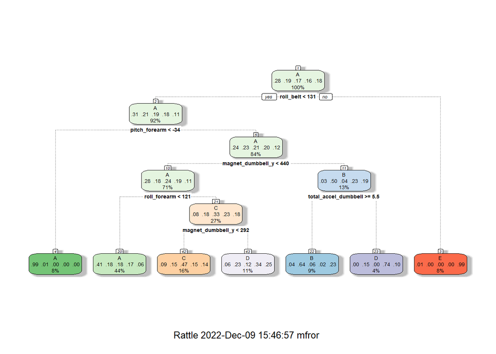

```r
fancyRpartPlot(modFit$finalModel)
```

## Test Forecast

```r
modPred <- predict(modFit, train.test)
confusionMatrix(factor(train.test$classe), modPred)
```

```
## Confusion Matrix and Statistics
##
##           Reference
## Prediction    A    B    C    D    E
##          A 1518   27   84   40    5
##          B  442  367  123  207    0
##          C  488   31  438   69    0
##          D  409    9  164  382    0
##          E  166  121  131  171  493
##
## Overall Statistics
##
##                Accuracy : 0.5434
##                  95% CI : (0.5306, 0.5562)
##     No Information Rate : 0.5137
##     P-Value [Acc > NIR] : 2.623e-06
##
##                   Kappa : 0.4055
##
##  Mcnemar's Test P-Value : < 2.2e-16
##
## Statistics by Class:
##
##                      Class: A Class: B Class: C Class: D Class: E
## Sensitivity            0.5022  0.66126  0.46596  0.43959  0.98996
## Specificity            0.9455  0.85516  0.88109  0.88397  0.89066
## Pos Pred Value         0.9068  0.32221  0.42690  0.39627  0.45564
## Neg Pred Value         0.6426  0.96039  0.89669  0.90104  0.99896
## Prevalence             0.5137  0.09431  0.15973  0.14766  0.08462
## Detection Rate         0.2579  0.06236  0.07443  0.06491  0.08377
## Detection Prevalence   0.2845  0.19354  0.17434  0.16381  0.18386
## Balanced Accuracy      0.7238  0.75821  0.67352  0.66178  0.94031
```

Setting up a Random Forest model

```r
rfFit <-randomForest(as.factor(classe) ~ ., data= train.train, importance = TRUE, ntrees = 10 )

rftrain <- predict(rfFit, train.train)
rftest  <- predict(rfFit, train.test)
confusionMatrix(factor(train.test$classe), rftest)
```

```
## Confusion Matrix and Statistics
##
##           Reference
## Prediction    A    B    C    D    E
##          A 1673    1    0    0    0
##          B    5 1133    1    0    0
##          C    0    2 1024    0    0
##          D    0    0    8  954    2
##          E    0    0    0    0 1082
##
## Overall Statistics
##
##                Accuracy : 0.9968
##                  95% CI : (0.995, 0.9981)
##     No Information Rate : 0.2851
##     P-Value [Acc > NIR] : < 2.2e-16
##
##                   Kappa : 0.9959
##
##  Mcnemar's Test P-Value : NA
##
## Statistics by Class:
##
##                      Class: A Class: B Class: C Class: D Class: E
## Sensitivity            0.9970   0.9974   0.9913   1.0000   0.9982
## Specificity            0.9998   0.9987   0.9996   0.9980   1.0000
## Pos Pred Value         0.9994   0.9947   0.9981   0.9896   1.0000
## Neg Pred Value         0.9988   0.9994   0.9981   1.0000   0.9996
## Prevalence             0.2851   0.1930   0.1755   0.1621   0.1842
## Detection Rate         0.2843   0.1925   0.1740   0.1621   0.1839
## Detection Prevalence   0.2845   0.1935   0.1743   0.1638   0.1839
## Balanced Accuracy      0.9984   0.9980   0.9954   0.9990   0.9991
```

## Running the Forecast

Finally the forecast is run for the file provided after applying a filter to remove any columns not used in the model creation. The forecast is run using the random forest approach.

```r
nm.train <- colnames(train.train)
nm.forec <- colnames(testing)
filter <- c()
for (nm in nm.forec) {
  if (nm %in% nm.train) {
    filter <- c(filter, TRUE)
  } else {
    filter <- c(filter, FALSE)
  }
}

predict(rfFit, testing[,filter])
```

```
##  1  2  3  4  5  6  7  8  9 10 11 12 13 14 15 16 17 18 19 20
##  B  A  B  A  A  E  D  B  A  A  B  C  B  A  E  E  A  B  B  B
## Levels: A B C D E
```

## Conclusion

The random forest approach was proved to be fairly accurate in the grouping of the data.